# Craft Beer Analysis

Nicole Norelli & Allen Miller

10/15/2020

# Craft Beer and Brewery Analysis

## An examination of ABV, IBU, Beer types (particularly IPA & Ale), and geographical trends

### Load necessary libraries and data

### Determine missing values

```
## Brew_ID    Name    City   State
##       0       0       0       0
```

```
##       Name    Beer_ID        ABV        IBU Brewery_id      Style     Ounces
##          0          0         62       1005          0          0          0
```

## Missing Values:

### There are 1005 (41.7%) missing IBU values and 62 (2.6%) missing ABV values

### We will determine if imputing missing values improves any machine learning techniques we apply.

# Number of Breweries per State

## Create table and heatmap

| State | n |
| --- | --- |
| AK | 7 |
| AL | 3 |
| AR | 2 |
| AZ | 11 |
| CA | 39 |
| CO | 47 |
| CT | 8 |
| DC | 1 |
| DE | 2 |
| FL | 15 |

[output cut: 41 more lines]

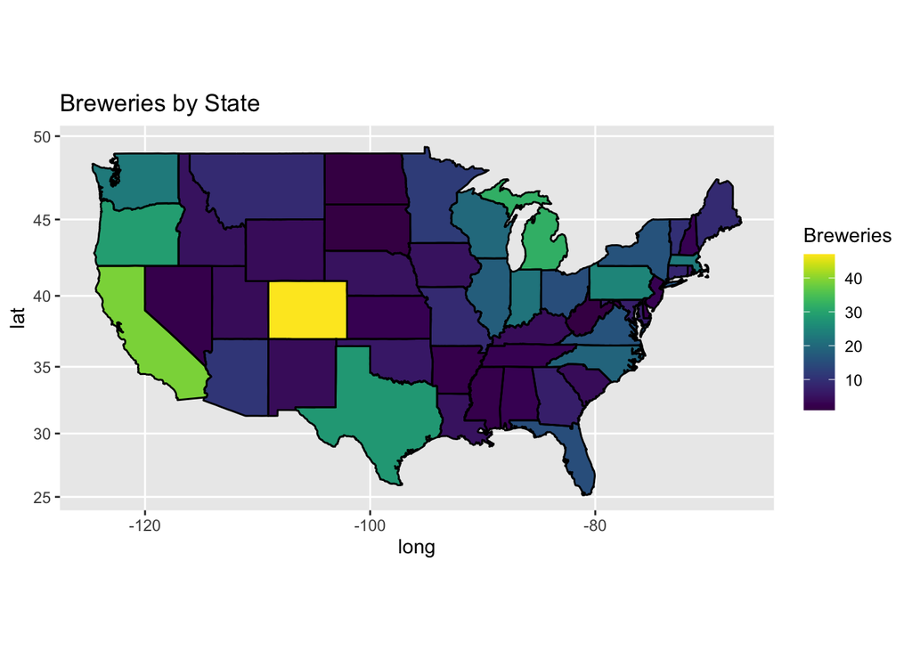

## Breweries per State:

### Colorado has the most with 47, followed by California with 39.

### All states and Washington, D.C. have breweries.

# Merge breweries and beer datasets

```
##   Brew_ID       Brewery_Name        City State     Beer_Name Beer_ID   ABV IBU
## 1       1 NorthGate Brewing  Minneapolis    MN  Get Together    2692 0.045  50
## 2       1 NorthGate Brewing  Minneapolis    MN Maggie's Leap    2691 0.049  26
## 3       1 NorthGate Brewing  Minneapolis    MN    Wall's End    2690 0.048  19
## 4       1 NorthGate Brewing  Minneapolis    MN       Pumpion    2689 0.060  38
## 5       1 NorthGate Brewing  Minneapolis    MN    Stronghold    2688 0.060  25
## 6       1 NorthGate Brewing  Minneapolis    MN   Parapet ESB    2687 0.056  47
##                                 Style Ounces
## 1                        American IPA     16
## 2                  Milk / Sweet Stout     16
## 3                   English Brown Ale     16
## 4                         Pumpkin Ale     16
## 5                     American Porter     16
## 6 Extra Special / Strong Bitter (ESB)     16
```

```
##      Brew_ID                  Brewery_Name          City State
## 2405     556         Ukiah Brewing Company         Ukiah    CA
## 2406     557       Butternuts Beer and Ale Garrattsville    NY
## 2407     557       Butternuts Beer and Ale Garrattsville    NY
## 2408     557       Butternuts Beer and Ale Garrattsville    NY
## 2409     557       Butternuts Beer and Ale Garrattsville    NY
## 2410     558 Sleeping Lady Brewing Company     Anchorage    AK
##                      Beer_Name Beer_ID   ABV IBU                   Style Ounces
## 2405             Pilsner Ukiah      98 0.055  NA         German Pilsener     12
## 2406  Heinnieweisse Weissebier      52 0.049  NA              Hefeweizen     12
## 2407           Snapperhead IPA      51 0.068  NA            American IPA     12
## 2408         Moo Thunder Stout      50 0.049  NA      Milk / Sweet Stout     12
## 2409         Porkslap Pale Ale      49 0.043  NA American Pale Ale (APA)     12
## 2410 Urban Wilderness Pale Ale      30 0.049  NA        English Pale Ale     12
```

# Compute median ABV and IBU for each state

## Create bar charts

| State | IBU |
| --- | --- |
| AK | 46 |
| AL | 43 |
| AR | 39 |
| AZ | 20.5 |
| CA | 42 |
| CO | 40 |
| CT | 29 |
| DC | 47.5 |
| DE | 52 |
| FL | 55 |

[output cut: 40 more lines]

| State | ABV |
| --- | --- |
| AK | 0.056 |
| AL | 0.06 |
| AR | 0.052 |
| AZ | 0.055 |
| CA | 0.058 |
| CO | 0.0605 |
| CT | 0.06 |
| DC | 0.0625 |
| DE | 0.055 |
| FL | 0.057 |

[output cut: 41 more lines]

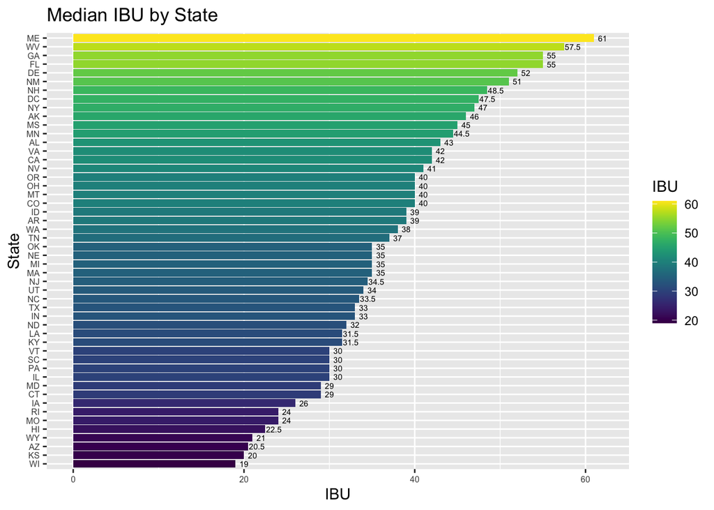

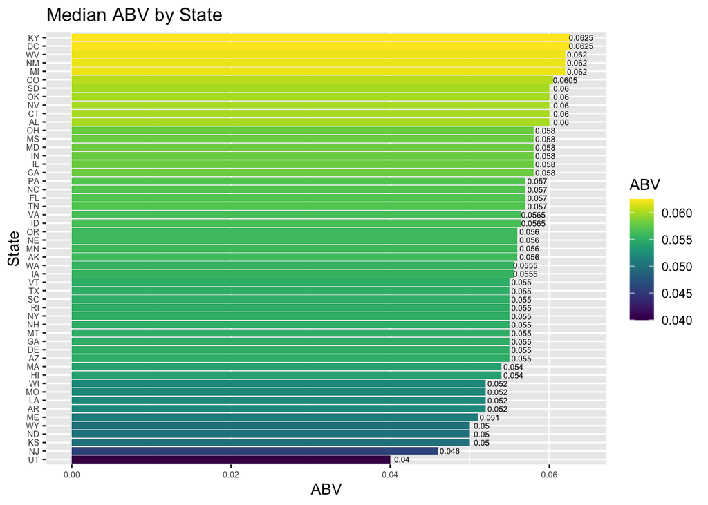

## Median ABV by State:

### Ranges from 0.04 (UT) to 0.0625 (KY)

## Median IBU by State:

### Ranges from 19 (Wisconsin) to 61 (Maine)

# Identify state with maximum ABV beer and state with maximum IBU beer

```
##     Brew_ID            Brewery_Name    City State
## 375      52 Upslope Brewing Company Boulder    CO
##                                                Beer_Name Beer_ID   ABV IBU
## 375 Lee Hill Series Vol. 5 - Belgian Style Quadrupel Ale    2565 0.128  NA
##                Style Ounces
## 375 Quadrupel (Quad)   19.2
```

```
##      Brew_ID            Brewery_Name    City State                 Beer_Name
## 1857     375 Astoria Brewing Company Astoria    OR Bitter Bitch Imperial IPA
##      Beer_ID   ABV IBU                          Style Ounces
## 1857     980 0.082 138 American Double / Imperial IPA     12
```

## State with maximum ABV beer:

### Colorado (Lee Hill Series Vol. 5 - Belgian Style Quadrupel Ale) ABV: 0.128

## State with maximum IBU beer:

### Oregon (Bitter Bitch Imperial IPA) IBU: 138

# Summary statistics and distribution of ABV

```
##    Min. 1st Qu.  Median    Mean 3rd Qu.    Max.    NA's
## 0.00100 0.05000 0.05600 0.05977 0.06700 0.12800      62
```

```
## [1] 0.01354173
```

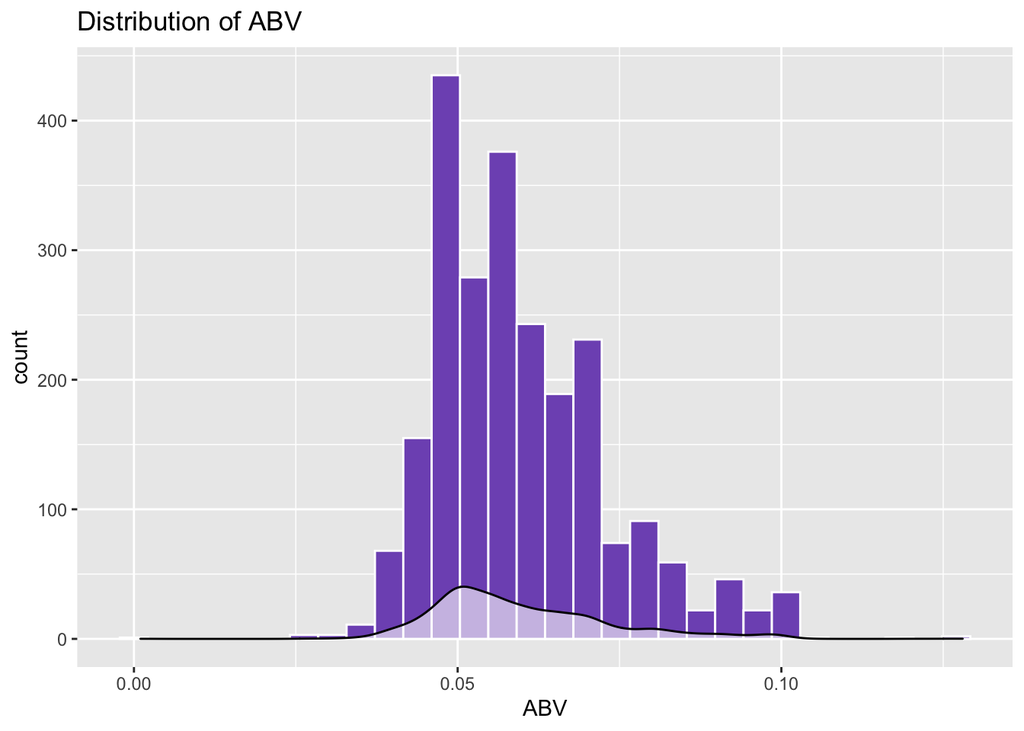

## Summary Statistics:

### Min: 0.001 Median: 0.056 Max: 0.128 Standard Deviation: 0.0135

## Distribution:

# Relationship between bitterness and alcohol content: scatterplot to visualize

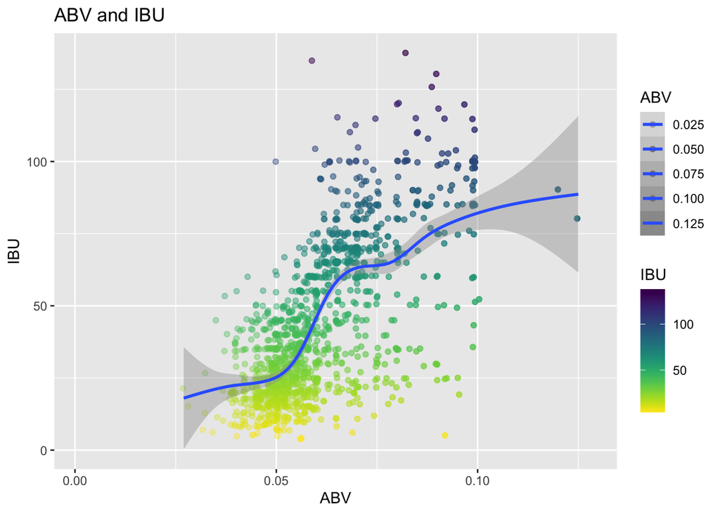

## Higher IBU appears associated with higher ABV

### Possible explanation: High IBU beers have more hops and are more bitter.

### To balance bitterness, more malt(suger) is added.

### This sugar and yeast produce higher ABV.

# Investigate difference with respect to IBU and ABV between IPAs and other Ales

### Replace missing IBU values with median IBU of each style

### Make dataframe with only Ales and IPAs and standardize values

### Find optimal number for nearest neighbor classification

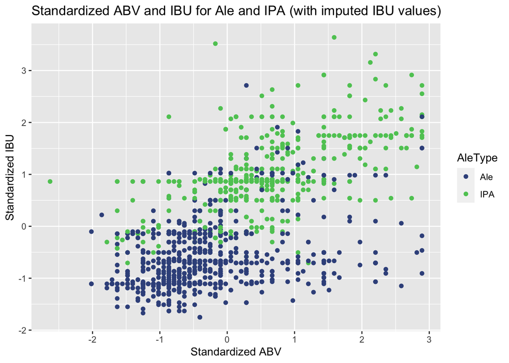

```
## Confusion Matrix and Statistics
##
##
## classifications Ale IPA
##             Ale 853  76
##             IPA  78 484
##
##                Accuracy : 0.8967
##                  95% CI : (0.8801, 0.9117)
##     No Information Rate : 0.6244
##     P-Value [Acc > NIR] : <2e-16
##
##                   Kappa : 0.7799
##
##  Mcnemar's Test P-Value : 0.9358
##
##             Sensitivity : 0.9162
##             Specificity : 0.8643
##          Pos Pred Value : 0.9182
##          Neg Pred Value : 0.8612
##              Prevalence : 0.6244
##          Detection Rate : 0.5721
##    Detection Prevalence : 0.6231
##       Balanced Accuracy : 0.8903
##
##        'Positive' Class : Ale
##
```

## Ale is associated with lower ABV and IBU compared to IPA

### Using the 29 nearest data points, our model uses ABV and IBU to predict IPA vs. Ale with 89% accuracy.

# Regional trends regarding ABV and IBU

## Using 4 US Census regions, examine ABV and IBU

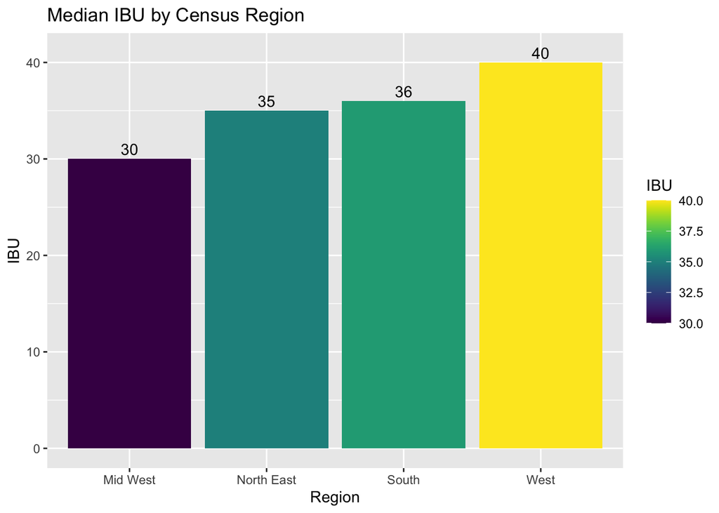

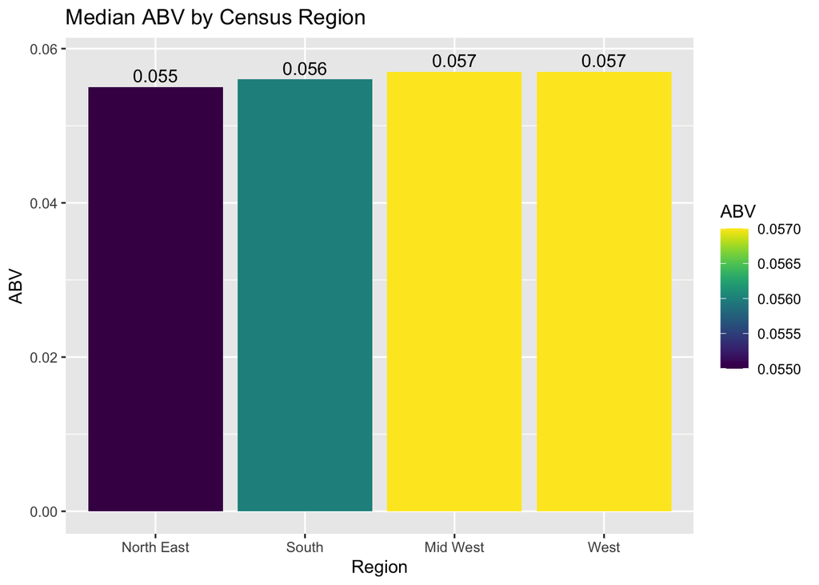

## The West Region had the highest median IBU level.

### Given that Oregon is part of the West, and had the beer with the single highest IBU level, it is unsuprising that the West is the highest.

## The West and Mid West both have the highest median ABV levels

### There is very little discrepancy between all four regions and more data could change this distribution

# Regional trends and major beer categories

### Group beer styles into seven major groups: IPA/Pale Ale, Ale, Pilsner, Lager, Stout, Wheat, and Other

### Examine category by census region

Totals per Category

| Category | n |
| --- | --- |
| IPA or Pale Ale | 870 |
| Ale | 630 |
| Other | 331 |
| Wheat | 211 |
| Lager | 177 |
| Stout | 100 |
| Pilsner | 91 |

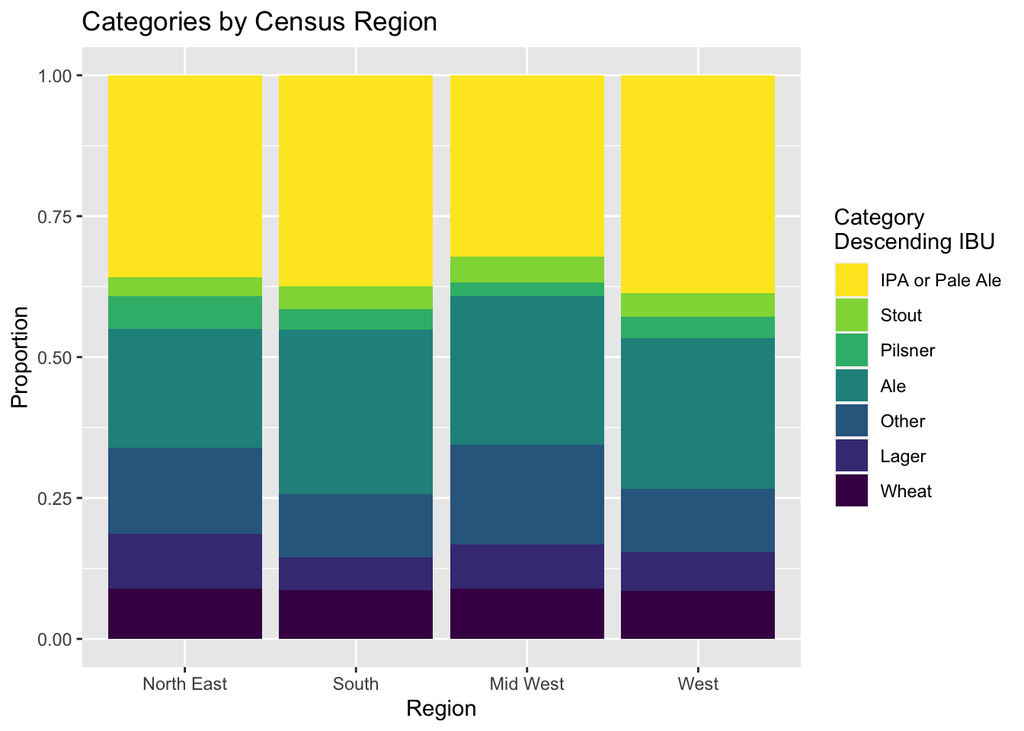

## IPA and Ale are the most common of the seven categories in all regions

### Proportion of each type of craft beer produced by region is similar

# Examine major beer groups by state

| State | Category | n |
| --- | --- | --- |
| AK | Ale | 11 |
| AK | IPA or Pale Ale | 10 |
| AK | Wheat | 2 |
| AK | Pilsner | 1 |
| AK | Stout | 1 |
| AL | IPA or Pale Ale | 5 |
| AL | Ale | 3 |
| AL | Stout | 2 |
| AR | Ale | 1 |
| AR | IPA or Pale Ale | 1 |

[output cut: 273 more lines]

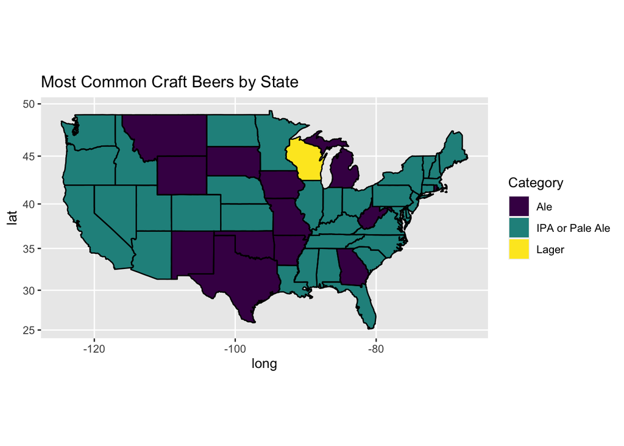

### 13 states had Ale as the most common type of craft beer produced.

### Only one state (WI) had a type of beer other than Ale or IPA as the most common beer type in production.

### There seems to be a general demand for IPA and Pale Ale, particularly on the east and west coasts